# lab5 team

Jonathan Kelly

11/8/2020

## Question 1

```r
acc$DAY_WEEK <- as.factor(acc$DAY_WEEK)
levels(acc$DAY_WEEK) <- c("Sunday", "Monday", "Tuesday", "Wensday", "Thursday", "Friday", "Saturday")
acc %>% group_by(DAY_WEEK) %>% summarise(total = n()) %>% arrange(desc(total))
```

```
## # A tibble: 7 x 2
##   DAY_WEEK total
##   <fct>    <int>
## 1 Saturday  5873
## 2 Sunday    5360
## 3 Friday    5358
## 4 Thursday  4621
## 5 Monday    4374
## 6 Tuesday   4347
## 7 Wensday   4314
```

The weekend has the most accidents with Saturday having the most and Friday and Sunday having similar values but still fairly far ahead compared to the 4th highest day.

## Question 2

```r
fatalAcc <- per %>% filter(INJ_SEV == 4)
head(fatalAcc)
```

```
##   STATE ST_CASE VE_FORMS VEH_NO PER_NO STR_VEH COUNTY DAY MONTH HOUR MINUTE
## 1     1   10001        1      1      1       0     73  19     2   23     35
## 2     1   10002        1      1      1       0     89  14     2   14     59
## 3     1   10003        3      2      1       0    101  31     1   20     31
## 4     1   10004        1      1      1       0     73   1     1   16     55
## 5     1   10005        1      1      1       0     13   1     1   20      0
## 6     1   10006        2      1      1       0     49   6     1   18     40
##   RUR_URB FUNC_SYS HARM_EV MAN_COLL SCH_BUS MAKE MAK_MOD BODY_TYP MOD_YEAR
## 1       2        1      38        0       0   20   20421       15     2004
## 2       2        1       1        0       0   37   37402       14     2005
## 3       2        1      12        1       0    2    2404       14     2003
## 4       2        4      30        0       0   30   30046        4     2014
## 5       1        1      35        0       0   12   12471       34     2010
## 6       1        1      34        0       0   49   49032        4     1997
##   TOW_VEH SPEC_USE EMER_USE ROLLOVER IMPACT1 FIRE_EXP AGE SEX PER_TYP INJ_SEV
```

[output cut: 41 more lines]

Filtering the dataset where INJ_SER is equal to 4, or where the accident is fatal according to the manual.

## Question 3

```r
InjuriesForMakeAndState <- per %>% select(STATE, INJ_SEV, MAKE) %>% filter(INJ_SEV == 4)

totalFatalPerMakeAndState <- InjuriesForMakeAndState %>% group_by(STATE, MAKE) %>% summarize(total = sum(INJ_SEV)) %>% arrange(desc(total))
totalFatalPerMakeAndState <- na.omit(totalFatalPerMakeAndState)
totalFatalPerMakeAndState <- totalFatalPerMakeAndState %>% group_by(STATE) %>% slice(1)

head(totalFatalPerMakeAndState)
```

```
## # A tibble: 6 x 3
## # Groups:   STATE [6]
##   STATE  MAKE total
##   <int> <int> <int>
## 1     1    12   552
## 2     2    12    36
## 3     4    20   352
## 4     5    20   352
## 5     6    49  1404
## 6     8    12   252
```

## Question 4

```r
GLC$`State Code` = as.numeric(GLC$`State Code`)
totalFatalPerMakeAndState$MAKE = as.factor(totalFatalPerMakeAndState$MAKE)

dangerousMakeState= totalFatalPerMakeAndState %>%
  left_join(GLC %>% select(c('State Name', 'State Code')), by = c('STATE' = 'State Code')) %>%
  unique() %>% mutate(`State Name` = tolower(`State Name`)) %>%
  left_join(states %>% select(long, lat, region), by = c('State Name' = 'region'))

dangerMakeLocation = dangerousMakeState %>%
  group_by(STATE, MAKE) %>%
  summarise(long = mean(long, na.rm = TRUE), lat = mean(lat, na.rm = TRUE))
```

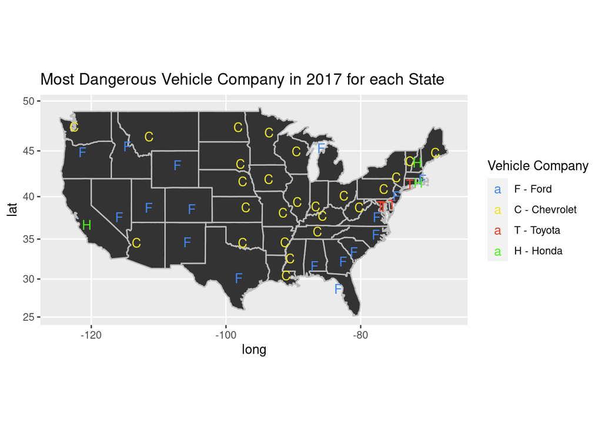

```r
levels(dangerMakeLocation$MAKE) =  c("F", "C", "T", "H")

ggplot(states, aes(x = long, y = lat)) +
  geom_polygon(aes(group = group)) +
  geom_path(aes(group = group), color = 'grey') +
  geom_text(data = dangerMakeLocation, aes(x = long, y = lat, label = MAKE, color = MAKE)) +
  coord_map() + ggtitle('Most Dangerous Vehicle Company in 2017 for each State') +
  labs(color = 'Vehicle Company') +
  scale_color_manual(values = c("#4287f5", "#ebe42a", "#f03f24", "#4df21b"), labels = c("F - Ford", "C - Chevrolet", "T - Toyota", "H - Honda"))
```

Chevrolet and Ford have a the majority of the most fatal vehicles by state, interestingly Chevy is mostly in the mid west and ford closer to the coasts.

## Question 5

```r
accidentsAndPeople <- inner_join(acc, per, by="ST_CASE")
head(accidentsAndPeople)
```

```
##   STATE.x ST_CASE VE_TOTAL VE_FORMS.x PVH_INVL PEDS PERNOTMVIT PERMVIT PERSONS
## 1       1   10001        1          1        0    0          0       1       1
## 2       1   10002        1          1        0    0          0       1       1
## 3       1   10003        3          3        0    0          0       3       3
## 4       1   10003        3          3        0    0          0       3       3
## 5       1   10003        3          3        0    0          0       3       3
## 6       1   10004        1          1        0    0          0       1       1
##   COUNTY.x CITY DAY.x MONTH.x YEAR DAY_WEEK HOUR.x MINUTE.x NHS RUR_URB.x
## 1       73  330    19       2 2017   Sunday     23       35   1         2
## 2       89 1730    14       2 2017  Tuesday     14       59   1         2
## 3      101 2130    31       1 2017  Tuesday     20       31   1         2
## 4      101 2130    31       1 2017  Tuesday     20       31   1         2
## 5      101 2130    31       1 2017  Tuesday     20       31   1         2
## 6       73  350     1       1 2017   Sunday     16       55   0         2
##   FUNC_SYS.x RD_OWNER ROUTE        TWAY_ID       TWAY_ID2 MILEPT LATITUDE
```

[output cut: 83 more lines]

## Question 6

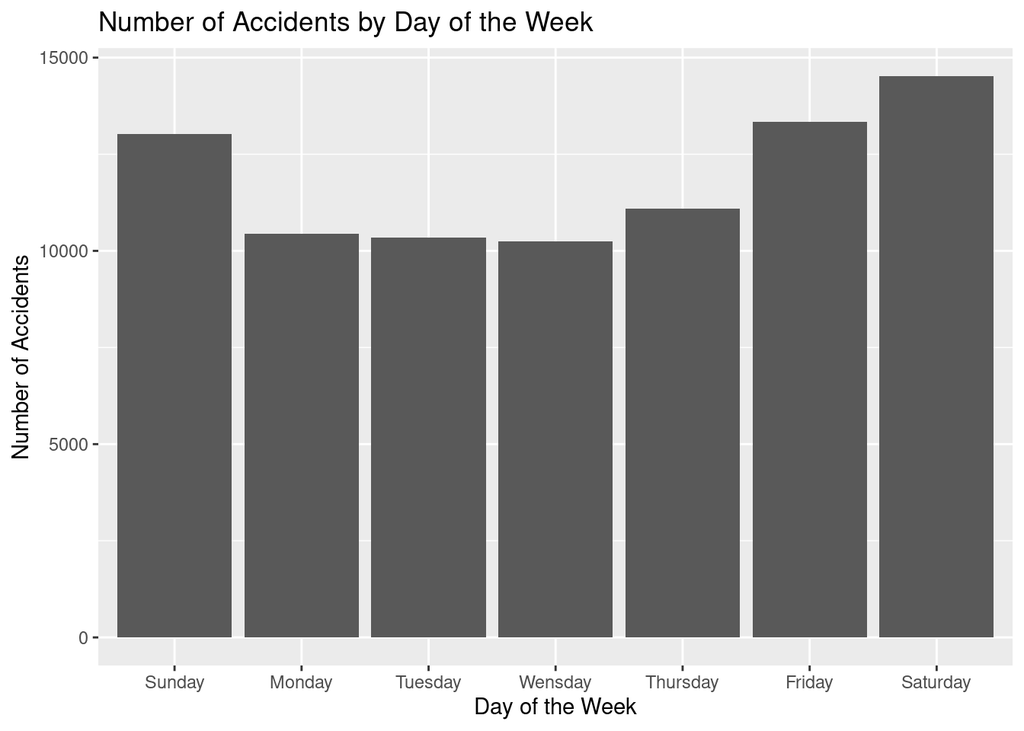

```r
filteredAccidentsAndPeople <- accidentsAndPeople %>%
  filter(HOUR.x >= 0 & HOUR.x <= 23)%>%
  filter(SEX == 1 | SEX == 2)

filteredAccidentsAndPeople$DAY_WEEK = as.factor(filteredAccidentsAndPeople$DAY_WEEK)
levels(filteredAccidentsAndPeople$DAY_WEEK) <- c("Sunday", "Monday", "Tuesday", "Wensday", "Thursday", "Friday", "Saturday")
filteredAccidentsAndPeople$SEX = as.factor(filteredAccidentsAndPeople$SEX)
levels(filteredAccidentsAndPeople$SEX) =  c("Male", "Female")

filteredAccidentsAndPeople%>%
  group_by(DAY_WEEK)%>%
  tally()%>%
  ggplot(aes(x = DAY_WEEK, y = n)) +
  geom_bar(stat='identity')+
  ggtitle("Number of Accidents by Day of the Week")+
  ylab("Number of Accidents")+
  xlab("Day of the Week")
```

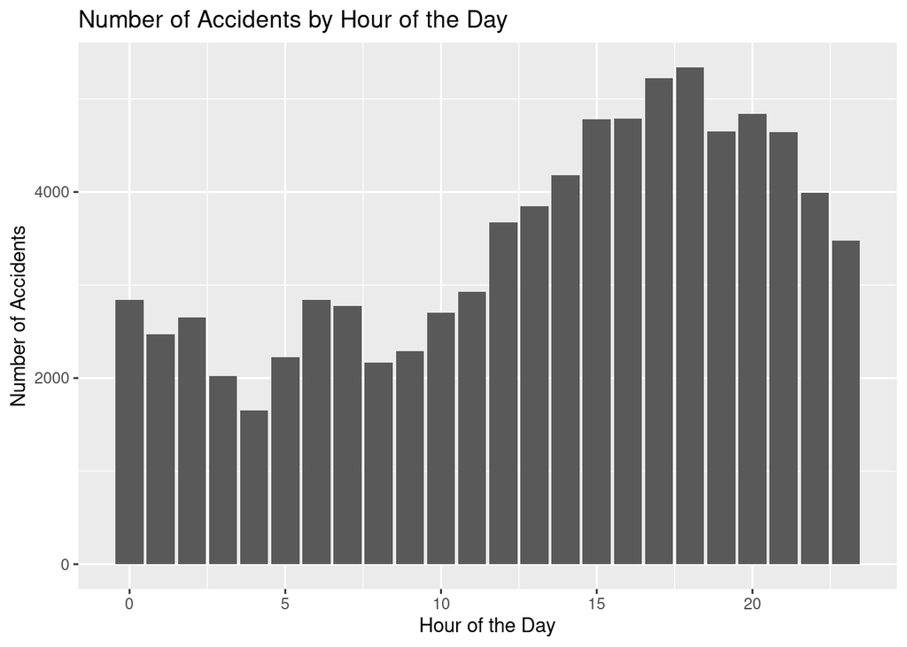

```r
filteredAccidentsAndPeople%>%
  group_by(HOUR.x)%>%
  tally()%>%
  ggplot(aes(x = HOUR.x, y = n)) +
  geom_bar(stat='identity')+
  ggtitle("Number of Accidents by Hour of the Day")+
  xlab("Hour of the Day")+
  ylab("Number of Accidents")
```

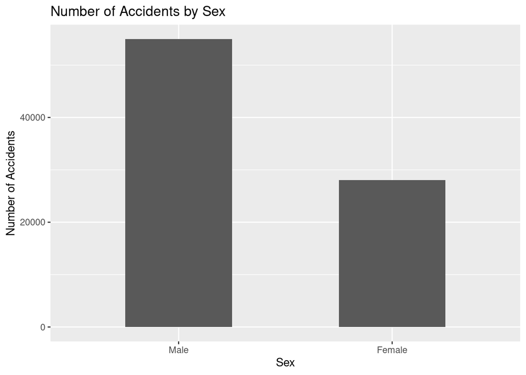

```r
filteredAccidentsAndPeople%>%
  group_by(SEX)%>%
  tally()%>%
  ggplot(aes(x = SEX, y = n)) +
  geom_bar(stat='identity', width = 0.5)+
  ggtitle("Number of Accidents by Sex")+
  xlab("Sex")+
  ylab("Number of Accidents")
```

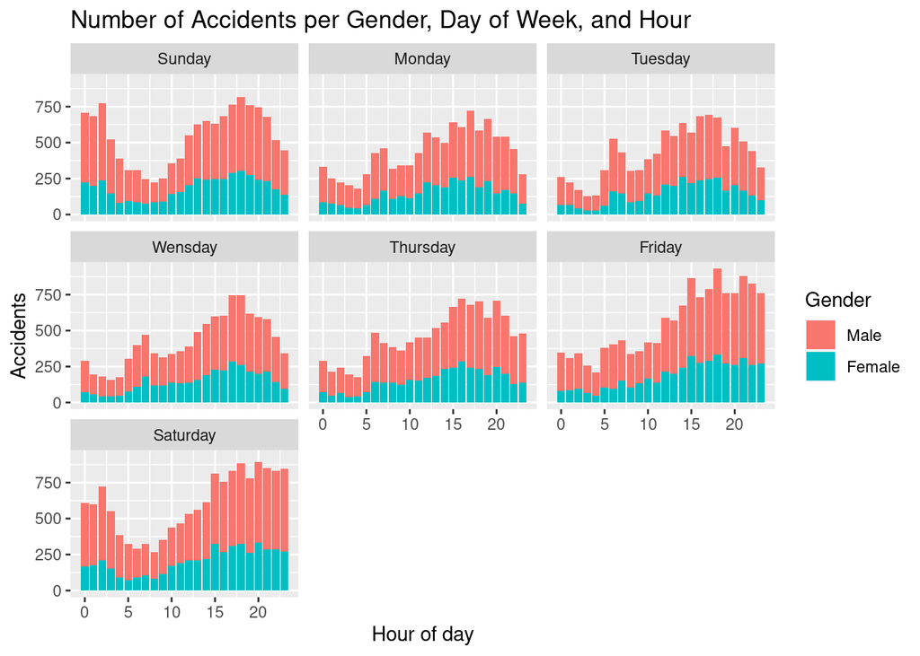

```r
filteredAccidentsAndPeople %>%
  group_by(DAY_WEEK, HOUR.x, SEX) %>%
  summarise(total = n(), .groups = 'drop') %>%
  ggplot(aes(x = HOUR.x, y = total, fill = SEX)) +
  geom_bar(stat = 'identity') +
  facet_wrap(~DAY_WEEK) +
  ggtitle('Number of Accidents per Gender, Day of Week, and Hour') +
  xlab('Hour of day') +
  ylab('Accidents') +
  labs(fill = 'Gender')
```

The weekend has the most accidents with Saturday having the most, with most accidents occurring from 4-6 which would correspond with rush hour traffic, and males have more accidents than Females.

## Question7

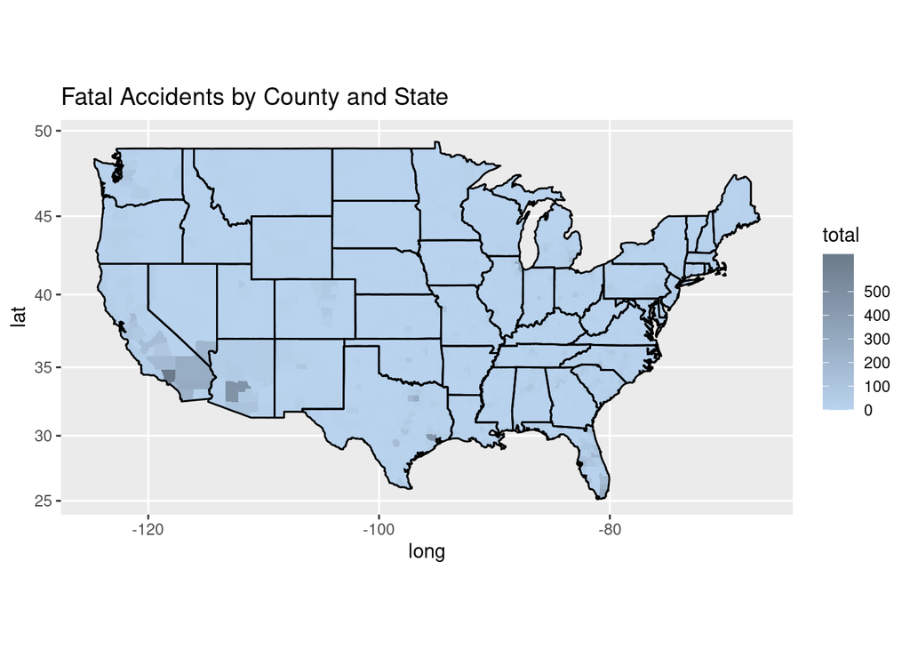

```r
countryData <- map_data("county")
GLC$`State Name` <- tolower(GLC$`State Name`)
GLC$`County Name`<- tolower(GLC$`County Name`)

countryData <- countryData %>% left_join(GLC, by = c('region' = 'State Name', 'subregion' = 'County Name'))

countryData$`County Code` <- as.numeric(countryData$`County Code`)
countryData$`State Code` <- as.numeric(countryData$`State Code`)

fatalAccByStateAndCounty <- fatalAcc %>%
  group_by(STATE, COUNTY) %>%
  summarize(total = n())
fatalAccByStateAndCounty <- fatalAccByStateAndCounty %>% right_join(countryData, by = c('COUNTY' = 'County Code', 'STATE'= 'State Code'))

fatalAccByStateAndCounty$total[is.na(fatalAccByStateAndCounty$total)] <- 0

ggplot(fatalAccByStateAndCounty, aes(x = long, y = lat, fill = total)) +
  geom_polygon(aes(group = group)) +
  geom_path(data = states, aes(x = long, y = lat, group = group), inherit.aes=FALSE, size= 0.5, color='black')+
  scale_fill_gradient2(low="slategray", mid="slategray2", high="slategray4" , breaks = c(0, 100,200,300,400,500)) +
  ggtitle('Fatal Accidents by County and State') + coord_map()
```

Counties around LA seem to be the most dangerous, which makes sense with how dense southern California is. Interestingly though Ney York and the north east seem very safe and the phoenix area seems much more dangerous that I would have expected.

## Question 8

```r
winter <- fatalAcc %>% filter(MONTH == 12 | MONTH == 1 | MONTH == 2)
summer <- fatalAcc %>% filter(MONTH == 6 | MONTH == 7 | MONTH == 8)

winter <- winter %>% group_by(STATE) %>% summarize(total = n()) %>% right_join(countryData, by = c("STATE" = "State Code"))
summer <- summer %>% group_by(STATE) %>% summarize(total = n()) %>% right_join(countryData, by = c("STATE" = "State Code"))
```

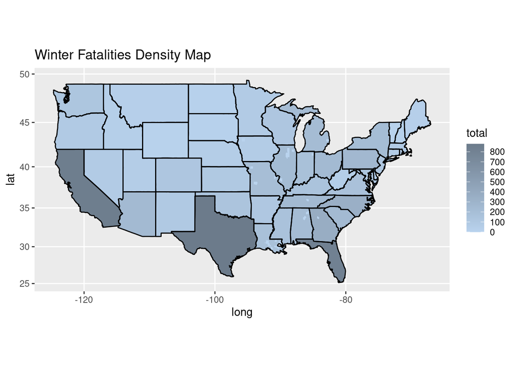

```r
winter$total[is.na(winter$total)] <- 0
summer$total[is.na(summer$total)] <- 0

b2 <- c(0, 100, 200, 300, 400, 500, 600, 700, 800, 900, 1000)

ggplot(winter, aes(x = long, y = lat, fill = total)) +
  geom_polygon(aes(group = group)) +
  geom_path(data = states, aes(x = long, y = lat, group = group), inherit.aes=FALSE, size= 0.5, color='black')+
  scale_fill_gradient2(low="slategray", mid = "slategray2" ,high="slategray4", breaks = b2) +ggtitle('Winter Fatalities Density Map') + coord_map()
```

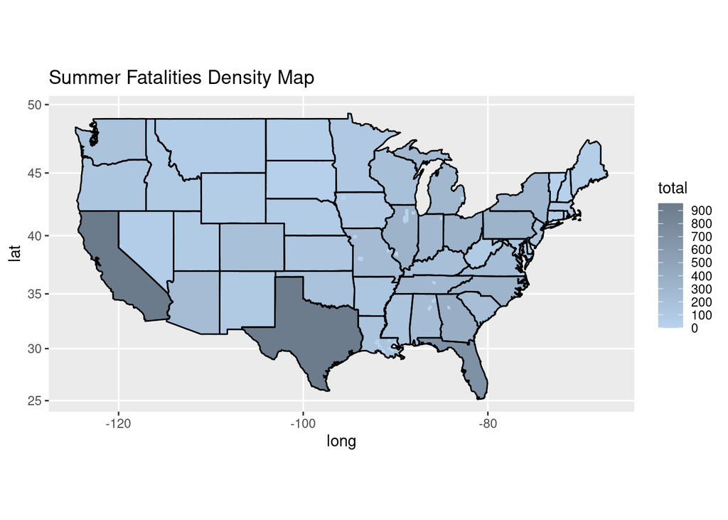

```r
ggplot(summer, aes(x = long, y = lat, fill = total)) +
  geom_polygon(aes(group = group)) +
  geom_path(data = states, aes(x = long, y = lat, group = group), inherit.aes=FALSE, size= 0.5, color='black')+
  scale_fill_gradient2(low="slategray", mid = "slategray2" ,high="slategray4", breaks = b2) + ggtitle('Summer Fatalities Density Map') + coord_map()
```